# Heart Attack Prediction

### Project Overview

Note: This is only a sample application and should not be considered as medical advice.

Generally, the data science project consists of seven steps which are problem definition, data collection, data preparation, data exploration, data modeling, model evaluation and model deployment.

#### Step 1: Problem Definition

This project is the capstone assignment for Udacity Machine Learning NanoDegree. It aims to model and predict the presence of heart disease in patients by using binary classification machine learning algorithm and a dataset of patient information, which can be found on Kaggle and UC Irvine's Machine Learning Repository.

#### Step 2: Data Collection

For this blog project, I decided to use the the heart disease UCI dataset taken from https://www.kaggle.com/ronitf/heart-disease-uci which is already a reprocessed data from UCI machine learning repository. This dataset have been taken back from 1988 and consisted of patients with admitted heart disease and chest pain symptoms from Cleveland.

#### Import libraries

Let's first import all the necessary libraries. I'll use numpy and pandas to start with.

For visualization, I will use pyplot subpackage of matplotlib, use rcParams to add styling to the plots and rainbow for colors. For implementing Machine Learning models, sagemaker libraries For processing the data, I'll import a few libraries. To split the available dataset for testing and training, I'll use the train_test_split method.

```python
# data managing and display libs
import pandas as pd
import numpy as np
import os

## Visualization
import matplotlib as mpl
import matplotlib.pyplot as plt
import seaborn as sns

from matplotlib import rcParams
rcParams['figure.figsize'] = 20,8
%matplotlib inline

# sagemaker libraries
import boto3
import sagemaker
from sagemaker import get_execution_role
#from sagemaker.inputs import TrainingInput
from sagemaker.amazon.amazon_estimator import get_image_uri
from sagemaker.predictor import csv_serializer, json_deserializer


from sklearn.metrics import accuracy_score
import sklearn.model_selection
from sklearn.preprocessing import StandardScaler
```

#### Import dataset

```python
heart_data = pd.read_csv('data/heart.csv')

heart_data.head()
```

|  | age | sex | cp | trestbps | chol | fbs | restecg | thalach | exang | oldpeak | slope | ca | thal | target |
| --- | --- | --- | --- | --- | --- | --- | --- | --- | --- | --- | --- | --- | --- | --- |
| 0 | 63 | 1 | 3 | 145 | 233 | 1 | 0 | 150 | 0 | 2.3 | 0 | 0 | 1 | 1 |
| 1 | 37 | 1 | 2 | 130 | 250 | 0 | 1 | 187 | 0 | 3.5 | 0 | 0 | 2 | 1 |
| 2 | 41 | 0 | 1 | 130 | 204 | 0 | 0 | 172 | 0 | 1.4 | 2 | 0 | 2 | 1 |
| 3 | 56 | 1 | 1 | 120 | 236 | 0 | 1 | 178 | 0 | 0.8 | 2 | 0 | 2 | 1 |
| 4 | 57 | 0 | 0 | 120 | 354 | 0 | 1 | 163 | 1 | 0.6 | 2 | 0 | 2 | 1 |

```python
heart_data.describe()
```

|  | age | sex | cp | trestbps | chol | fbs | restecg | thalach | exang | oldpeak | slope | ca | thal | target |
| --- | --- | --- | --- | --- | --- | --- | --- | --- | --- | --- | --- | --- | --- | --- |
| count | 303.000000 | 303.000000 | 303.000000 | 303.000000 | 303.000000 | 303.000000 | 303.000000 | 303.000000 | 303.000000 | 303.000000 | 303.000000 | 303.000000 | 303.000000 | 303.000000 |
| mean | 54.366337 | 0.683168 | 0.966997 | 131.623762 | 246.264026 | 0.148515 | 0.528053 | 149.646865 | 0.326733 | 1.039604 | 1.399340 | 0.729373 | 2.313531 | 0.544554 |
| std | 9.082101 | 0.466011 | 1.032052 | 17.538143 | 51.830751 | 0.356198 | 0.525860 | 22.905161 | 0.469794 | 1.161075 | 0.616226 | 1.022606 | 0.612277 | 0.498835 |
| min | 29.000000 | 0.000000 | 0.000000 | 94.000000 | 126.000000 | 0.000000 | 0.000000 | 71.000000 | 0.000000 | 0.000000 | 0.000000 | 0.000000 | 0.000000 | 0.000000 |
| 25% | 47.500000 | 0.000000 | 0.000000 | 120.000000 | 211.000000 | 0.000000 | 0.000000 | 133.500000 | 0.000000 | 0.000000 | 1.000000 | 0.000000 | 2.000000 | 0.000000 |
| 50% | 55.000000 | 1.000000 | 1.000000 | 130.000000 | 240.000000 | 0.000000 | 1.000000 | 153.000000 | 0.000000 | 0.800000 | 1.000000 | 0.000000 | 2.000000 | 1.000000 |
| 75% | 61.000000 | 1.000000 | 2.000000 | 140.000000 | 274.500000 | 0.000000 | 1.000000 | 166.000000 | 1.000000 | 1.600000 | 2.000000 | 1.000000 | 3.000000 | 1.000000 |
| max | 77.000000 | 1.000000 | 3.000000 | 200.000000 | 564.000000 | 1.000000 | 2.000000 | 202.000000 | 1.000000 | 6.200000 | 2.000000 | 4.000000 | 3.000000 | 1.000000 |

```python
heart_data.info()
```

```
<class 'pandas.core.frame.DataFrame'>
RangeIndex: 303 entries, 0 to 302
Data columns (total 14 columns):
 #   Column    Non-Null Count  Dtype
---  ------    --------------  -----
 0   age       303 non-null    int64
 1   sex       303 non-null    int64
 2   cp        303 non-null    int64
 3   trestbps  303 non-null    int64
 4   chol      303 non-null    int64
 5   fbs       303 non-null    int64
 6   restecg   303 non-null    int64
 7   thalach   303 non-null    int64
 8   exang     303 non-null    int64
 9   oldpeak   303 non-null    float64
 10  slope     303 non-null    int64
 11  ca        303 non-null    int64
 12  thal      303 non-null    int64
 13  target    303 non-null    int64
dtypes: float64(1), int64(13)
memory usage: 33.3 KB
```

#### Step 3. Data Exploration

##### Understanding the data

Now, we can use visualizations to better understand our data and then look at any processing we might want to do.

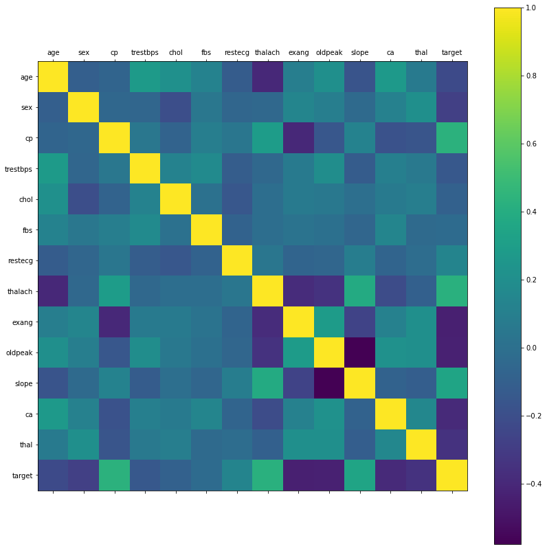

```python
rcParams['figure.figsize'] = 20, 14
plt.matshow(heart_data.corr())
plt.yticks(np.arange(heart_data.shape[1]), heart_data.columns)
plt.xticks(np.arange(heart_data.shape[1]), heart_data.columns)
plt.colorbar()
```

Taking a look at the correlation matrix above, it's easy to see that a few features have negative correlation with the target value while some have positive. Next, I'll take a look at the histograms for each variable.

```
array([[<AxesSubplot:title={'center':'age'}>,
        <AxesSubplot:title={'center':'sex'}>,
        <AxesSubplot:title={'center':'cp'}>,
        <AxesSubplot:title={'center':'trestbps'}>],
       [<AxesSubplot:title={'center':'chol'}>,
        <AxesSubplot:title={'center':'fbs'}>,
        <AxesSubplot:title={'center':'restecg'}>,
        <AxesSubplot:title={'center':'thalach'}>],
       [<AxesSubplot:title={'center':'exang'}>,
        <AxesSubplot:title={'center':'oldpeak'}>,
        <AxesSubplot:title={'center':'slope'}>,
        <AxesSubplot:title={'center':'ca'}>],
       [<AxesSubplot:title={'center':'thal'}>,
        <AxesSubplot:title={'center':'target'}>, <AxesSubplot:>,
        <AxesSubplot:>]], dtype=object)
```

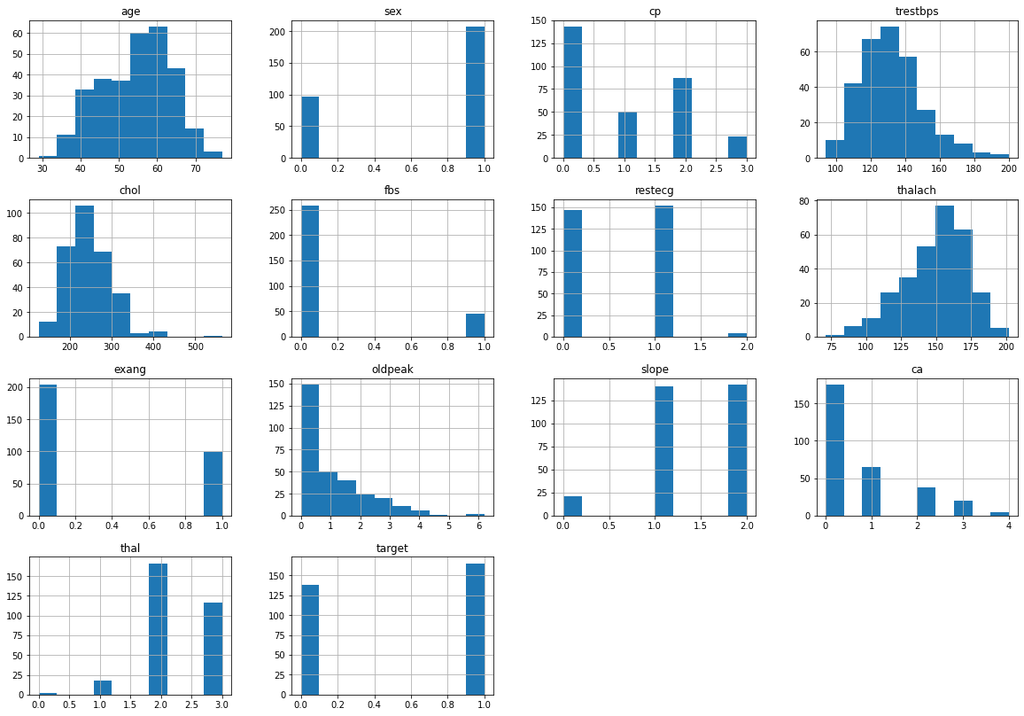

```python
heart_data.hist()
```

Taking a look at the histograms above, I can see that each feature has a different range of distribution. Thus, using scaling before our predictions should be of great use. Also, the categorical features do stand out.

It's always a good practice to work with a dataset where the target classes are of approximately equal size. Thus, let's check for the same.

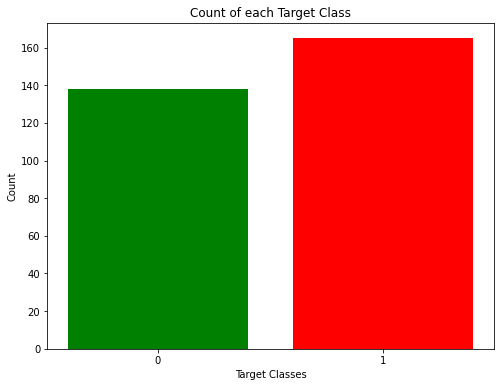

```python
rcParams['figure.figsize'] = 8,6
plt.bar(heart_data['target'].unique(), heart_data['target'].value_counts(), color = ['red', 'green'])
plt.xticks([0, 1])
plt.xlabel('Target Classes')
plt.ylabel('Count')
plt.title('Count of each Target Class')
```

The two classes are not exactly 50% each but the ratio is good enough to continue without dropping/increasing our data.

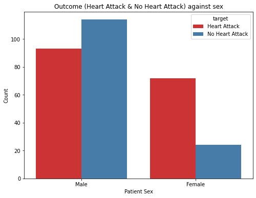

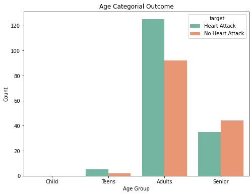

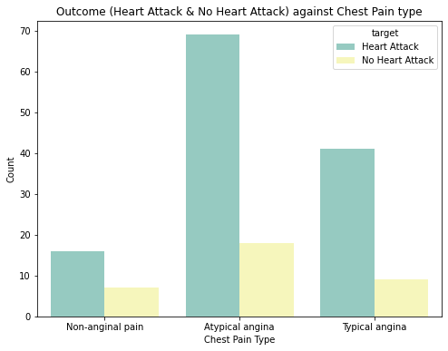

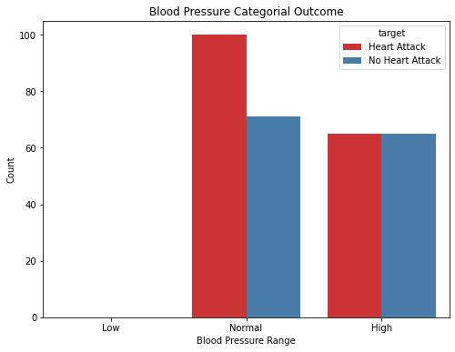

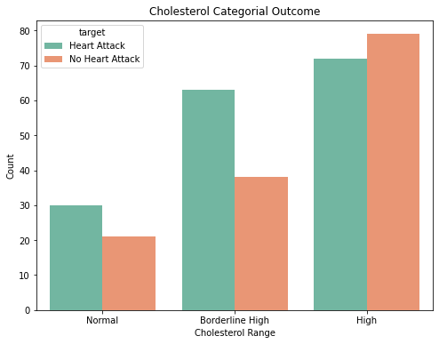

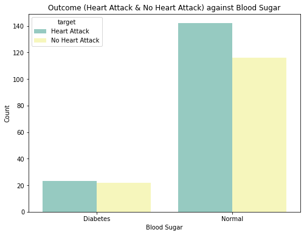

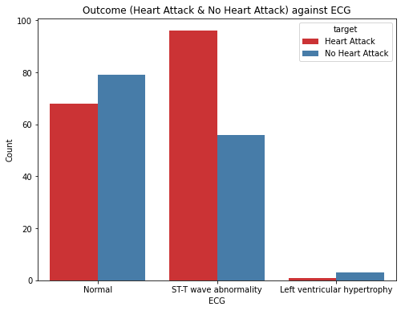

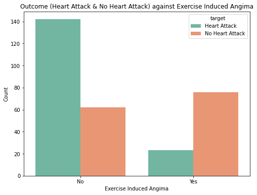

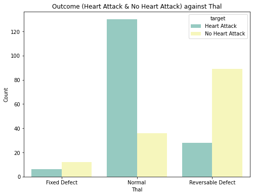

```python
dum_data = heart_data.copy()

ctar = {1: "Heart Attack", 0: "No Heart Attack"}
dum_data.target = dum_data.target.map(ctar)

### Data Distribution against sex

csex = {1: "Male", 0: "Female"}
dum_data.sex = dum_data.sex.map(csex)

ax = sns.countplot(x='sex', hue='target', palette = 'Set1', data = dum_data)
ax.set(title = "Outcome (Heart Attack & No Heart Attack) against sex", xlabel = 'Patient Sex', ylabel = 'Count' )
plt.show()

### Data Distribution against age group

age_group = (0, 18, 35, 60, 100)
labels = ['Child', 'Teens', 'Adults', 'Senior']
dum_data.age = pd.cut(dum_data.age, age_group, labels = labels)

ax = sns.countplot(x='age', hue='target', palette = 'Set2', data = dum_data)
ax.set(title = "Age Categorial Outcome", xlabel = 'Age Group', ylabel = 'Count' )
plt.show()

### Data Distribution against Chest Pain Type

ccp = {1: "Typical angina", 2: "Atypical angina", 3: "Non-anginal pain", 4: "Asymptomatic"}
dum_data.cp = dum_data.cp.map(ccp)

ax = sns.countplot(x='cp', hue='target', palette = 'Set3', data = dum_data)
ax.set(title = "Outcome (Heart Attack & No Heart Attack) against Chest Pain type", xlabel = 'Chest Pain Type', ylabel = 'Count' )
plt.show()

### Data Distribution against Blood Pressure

bp_range = (60, 90, 130, 190)
labels = ['Low','Normal', 'High']
dum_data.trestbps = pd.cut(dum_data.trestbps, bp_range, labels=labels)

ax = sns.countplot(x='trestbps', hue = 'target', palette = 'Set1', data = dum_data)
ax.set(title = "Blood Pressure Categorial Outcome", xlabel = "Blood Pressure Range" , ylabel = "Count")
plt.show()

### Data Distribution against Cholesterol

chol_range = (0, 200, 240, 600)
labels = ['Normal', 'Borderline High', 'High']
dum_data.chol = pd.cut(dum_data.chol, chol_range, labels=labels)

ax = sns.countplot(x='chol', hue = 'target', palette = 'Set2', data = dum_data)
ax.set(title = "Cholesterol Categorial Outcome", xlabel = "Cholesterol Range" , ylabel = "Count")
plt.show()

### Data Distribution against Fasting Blood Sugar

cfbs = {1: "Diabetes", 0: "Normal"}
dum_data.fbs = dum_data.fbs.map(cfbs)

ax = sns.countplot(x='fbs', hue='target', palette = 'Set3', data = dum_data)
ax.set(title = "Outcome (Heart Attack & No Heart Attack) against Blood Sugar", xlabel = 'Blood Sugar', ylabel = 'Count' )
plt.show()

### Data Distribution against Resting ECG Results

cecg = {0: "Normal", 1: "ST-T wave abnormality", 2: "Left ventricular hypertrophy"}
dum_data.restecg = dum_data.restecg.map(cecg)

ax = sns.countplot(x='restecg', hue='target', palette = 'Set1', data = dum_data)
ax.set(title = "Outcome (Heart Attack & No Heart Attack) against ECG", xlabel = 'ECG', ylabel = 'Count' )
plt.show()

### Data Distribution against Exercise Induced Angima

cexang = {0: "No", 1: "Yes"}
dum_data.exang = dum_data.exang.map(cexang)

ax = sns.countplot(x='exang', hue='target', palette = 'Set2', data = dum_data)
ax.set(title = "Outcome (Heart Attack & No Heart Attack) against Exercise Induced Angima", xlabel = 'Exercise Induced Angima', ylabel = 'Count' )
plt.show()

### Data Distribution against Thal

cthal = {2: "Normal", 1: "Fixed Defect", 3: "Reversable Defect"}
dum_data.thal = dum_data.thal.map(cthal)

ax = sns.countplot(x='thal', hue='target', palette = 'Set3', data = dum_data)
ax.set(title = "Outcome (Heart Attack & No Heart Attack) against Thal", xlabel = 'Thal', ylabel = 'Count' )
plt.show()
```

Taking a look at the categorical counts above, we can see the number of occurences for each category.

#### Step 4. Data Preparation

After exploring the dataset, I observed that I need to convert some categorical variables into dummy variables and scale all the values before training the Machine Learning models. First, I'll use the get_dummies method to create dummy columns for categorical variables.

```python
heart_data = pd.get_dummies(heart_data, columns = ['sex', 'cp', 'fbs', 'restecg', 'exang', 'slope', 'ca', 'thal'])
```

Now, I will use the StandardScaler from sklearn to scale my dataset.

```python
standardScaler = StandardScaler()
columns_to_scale = ['age', 'trestbps', 'chol', 'thalach', 'oldpeak']
heart_data[columns_to_scale] = standardScaler.fit_transform(heart_data[columns_to_scale])
```

```python
heart_data.head()
```

|  | age | trestbps | chol | thalach | oldpeak | target | sex_0 | sex_1 | cp_0 | cp_1 | ... | slope_2 | ca_0 | ca_1 | ca_2 | ca_3 | ca_4 | thal_0 | thal_1 | thal_2 | thal_3 |
| --- | --- | --- | --- | --- | --- | --- | --- | --- | --- | --- | --- | --- | --- | --- | --- | --- | --- | --- | --- | --- | --- |
| 0 | 0.952197 | 0.763956 | -0.256334 | 0.015443 | 1.087338 | 1 | 0 | 1 | 0 | 0 | ... | 0 | 1 | 0 | 0 | 0 | 0 | 0 | 1 | 0 | 0 |
| 1 | -1.915313 | -0.092738 | 0.072199 | 1.633471 | 2.122573 | 1 | 0 | 1 | 0 | 0 | ... | 0 | 1 | 0 | 0 | 0 | 0 | 0 | 0 | 1 | 0 |
| 2 | -1.474158 | -0.092738 | -0.816773 | 0.977514 | 0.310912 | 1 | 1 | 0 | 0 | 1 | ... | 1 | 1 | 0 | 0 | 0 | 0 | 0 | 0 | 1 | 0 |
| 3 | 0.180175 | -0.663867 | -0.198357 | 1.239897 | -0.206705 | 1 | 0 | 1 | 0 | 1 | ... | 1 | 1 | 0 | 0 | 0 | 0 | 0 | 0 | 1 | 0 |
| 4 | 0.290464 | -0.663867 | 2.082050 | 0.583939 | -0.379244 | 1 | 1 | 0 | 1 | 0 | ... | 1 | 1 | 0 | 0 | 0 | 0 | 0 | 0 | 1 | 0 |

5 rows × 31 columns

#### Machine Learning

In the cells below, I'm creating the train/test data. I'll use train_test_split to split our dataset into training and testing datasets. And get train/test features and labels.

```python
heart_data_y = heart_data.target
heart_data_X = heart_data.drop('target', axis=1)

# Split the data into the DataFrames train and test with test size 20%

train_X, test_X, train_y, test_y = sklearn.model_selection.train_test_split(heart_data_X, heart_data_y, test_size = 0.2)

train_X = train_X.reset_index(drop=True)
test_X = test_X.reset_index(drop=True)
train_y = train_y.reset_index(drop=True)
test_y = test_y.reset_index(drop=True)

print('Train dataset size: ')
print(train_X.shape)

print('Test dataset size: ')
print(test_X.shape)
```

```
Train dataset size:
(242, 30)
Test dataset size:
(61, 30)
```

#### Uploading Training & Test files to S3

```python
# store the current SageMaker session

session = sagemaker.Session()

# get IAM role

role = get_execution_role()
print(role)
```

```
arn:aws:iam::903656752510:role/service-role/AmazonSageMaker-ExecutionRole-20210409T134228
```

```python
# get default bucket

bucket_name = session.default_bucket()
print(bucket_name)
```

```
sagemaker-us-east-1-903656752510
```

```python
# define location to store model artifacts

prefix = 'heart_data'

output_path='s3://{}/{}/output'.format(bucket_name, prefix)

print('Training artifacts will be uploaded to: {}'.format(output_path))
```

```
Training artifacts will be uploaded to: s3://sagemaker-us-east-1-903656752510/heart_data/output
```

```python
train_X.iloc[:5]
```

|  | age | trestbps | chol | thalach | oldpeak | sex_0 | sex_1 | cp_0 | cp_1 | cp_2 | ... | slope_2 | ca_0 | ca_1 | ca_2 | ca_3 | ca_4 | thal_0 | thal_1 | thal_2 | thal_3 |
| --- | --- | --- | --- | --- | --- | --- | --- | --- | --- | --- | --- | --- | --- | --- | --- | --- | --- | --- | --- | --- | --- |
| 0 | -1.143291 | -1.234996 | -0.952051 | 1.196166 | -0.896862 | 0 | 1 | 1 | 0 | 0 | ... | 1 | 0 | 1 | 0 | 0 | 0 | 0 | 0 | 1 | 0 |
| 1 | -1.363869 | 0.478391 | -0.391612 | 1.239897 | -0.896862 | 0 | 1 | 1 | 0 | 0 | ... | 1 | 1 | 0 | 0 | 0 | 0 | 0 | 0 | 1 | 0 |
| 2 | 0.400752 | -1.806125 | 0.033549 | -1.209011 | -0.034166 | 1 | 0 | 1 | 0 | 0 | ... | 0 | 1 | 0 | 0 | 0 | 0 | 0 | 0 | 1 | 0 |
| 3 | 0.731619 | 0.135714 | -0.237008 | -0.203210 | 1.346147 | 0 | 1 | 0 | 0 | 0 | ... | 0 | 0 | 0 | 1 | 0 | 0 | 0 | 0 | 1 | 0 |
| 4 | -0.371269 | -0.663867 | 0.941846 | 0.321556 | -0.379244 | 1 | 0 | 0 | 0 | 1 | ... | 1 | 1 | 0 | 0 | 0 | 0 | 0 | 0 | 1 | 0 |

5 rows × 30 columns

```python
train_y.iloc[:5]
```

```
0    0
1    1
2    1
3    0
4    1
Name: target, dtype: int64
```

```python
test_X.iloc[:5]
```

|  | age | trestbps | chol | thalach | oldpeak | sex_0 | sex_1 | cp_0 | cp_1 | cp_2 | ... | slope_2 | ca_0 | ca_1 | ca_2 | ca_3 | ca_4 | thal_0 | thal_1 | thal_2 | thal_3 |
| --- | --- | --- | --- | --- | --- | --- | --- | --- | --- | --- | --- | --- | --- | --- | --- | --- | --- | --- | --- | --- | --- |
| 0 | 1.172774 | -0.663867 | -1.338561 | -0.421862 | -0.551783 | 0 | 1 | 1 | 0 | 0 | ... | 1 | 1 | 0 | 0 | 0 | 0 | 0 | 0 | 0 | 1 |
| 1 | -0.371269 | -1.806125 | -0.468914 | -0.290671 | 0.138373 | 0 | 1 | 0 | 0 | 1 | ... | 0 | 1 | 0 | 0 | 0 | 0 | 0 | 0 | 1 | 0 |
| 2 | -0.260980 | 0.364165 | -0.449589 | 0.846322 | -0.896862 | 0 | 1 | 0 | 0 | 1 | ... | 1 | 0 | 0 | 0 | 0 | 1 | 0 | 0 | 1 | 0 |
| 3 | -0.591847 | -0.092738 | 0.381407 | 0.933783 | -0.379244 | 0 | 1 | 0 | 1 | 0 | ... | 1 | 1 | 0 | 0 | 0 | 0 | 0 | 0 | 1 | 0 |
| 4 | -0.040403 | -1.234996 | -0.623518 | 0.365287 | 0.483451 | 1 | 0 | 0 | 0 | 1 | ... | 0 | 1 | 0 | 0 | 0 | 0 | 0 | 0 | 1 | 0 |

5 rows × 30 columns

```python
test_y.iloc[:5]
```

```
0    1
1    1
2    1
3    1
4    1
Name: target, dtype: int64
```

```python
# First we make sure that the local directory in which we'd like to store the training and test csv files exists.

data_dir = 'data'

if not os.path.exists(data_dir):
    os.makedirs(data_dir)
    print("True")
```

```python
# First, save the test data to test.csv in the data_dir directory.

pd.DataFrame(test_X).to_csv(os.path.join(data_dir, 'test.csv'), header=False, index=False)

# Save the training data to train.csv in the data_dir directory

pd.concat([pd.DataFrame(train_y), pd.DataFrame(train_X)], axis = 1).to_csv(os.path.join(data_dir, 'train.csv'), header = False, index = False)
```

```python
#test_X = train_X = val_X = train_y = val_y = None
```

```python
# Upload the test.csv and train.csv files which are contained in data_dir to S3 using session.upload_data().

test_location = session.upload_data(os.path.join(data_dir, 'test.csv'), key_prefix=prefix)
train_location = session.upload_data(os.path.join(data_dir,'train.csv'), key_prefix=prefix)

train_location
```

```
's3://sagemaker-us-east-1-903656752510/heart_data/train.csv'
```

#### Step 5. Data Modeling

Now that we've uploaded your training data, it's time to define and train a model!

To begin with, we need to do some setup by making use of Docker containers.

In this notebook, we'll define and train the XGBoost for binary classification effectively outputs labels; either 1 or 0

```python
from sagemaker.amazon.amazon_estimator import get_image_uri

container = get_image_uri(boto3.Session().region_name, 'xgboost', "latest")

xgb = sagemaker.estimator.Estimator(container,
                                       role,
                                       train_instance_count=1,
                                       train_instance_type='ml.m5.2xlarge',
                                       output_path=output_path,
                                       sagemaker_session=session)

xgb.set_hyperparameters(max_depth=5,
                        eta=0.2,
                        gamma=4,
                        min_child_weight=6,
                        subsample=0.8,
                        silent=0,
                        objective='binary:logistic',
                        early_stopping_rounds=15,
                        num_round=500)
```

```
'get_image_uri' method will be deprecated in favor of 'ImageURIProvider' class in SageMaker Python SDK v2.
There is a more up to date SageMaker XGBoost image. To use the newer image, please set 'repo_version'='1.0-1'. For example:
	get_image_uri(region, 'xgboost', '1.0-1').
Parameter image_name will be renamed to image_uri in SageMaker Python SDK v2.
```

Now that our model has been set up we simply need to attach the training dataset and then ask SageMaker to set up the computation.

```python
#from sagemaker.inputs import TrainingInput

s3_input_train = sagemaker.s3_input(s3_data=train_location, content_type='text/csv')

xgb.fit({'train': s3_input_train})
```

```
's3_input' class will be renamed to 'TrainingInput' in SageMaker Python SDK v2.
```

[output not shown]

[output cut: 41 more lines]

[output not shown]

#### Step 6. Model Deployment

After training, we have to deploy the trained model to create a predictor.

To deploy a trained model, we'll use .deploy.

```python
%%time

# deploy and create a predictor
# training_job = linear-learner-2021-04-21-17-57-00-733

predictor = xgb.deploy(initial_instance_count=1, instance_type='ml.t2.medium')
```

```
Parameter image will be renamed to image_uri in SageMaker Python SDK v2.
```

```
---------------!CPU times: user 263 ms, sys: 23.3 ms, total: 286 ms
Wall time: 7min 32s
```

#### Step 7. Model Evaluation

Once the model is deployed, we can see how it performs when applied to our test data.

The provided cell below, reads in the test data from s3 'test_location' path. The features are extracted from the test.csv file and labels are stored in test_y

```python
xgb_transformer = xgb.transformer(instance_count = 1, instance_type = 'ml.m4.xlarge')
```

```
Parameter image will be renamed to image_uri in SageMaker Python SDK v2.
Using already existing model: xgboost-2021-04-24-03-28-20-245
```

```python
xgb_transformer.transform(test_location, content_type='text/csv', split_type='Line')
```

```python
xgb_transformer.wait()
```

[output not shown]

```python
!aws s3 cp --recursive $xgb_transformer.output_path $data_dir
```

```
download: s3://sagemaker-us-east-1-903656752510/xgboost-2021-04-24-03-53-36-761/test.csv.out to data/test.csv.out
```

```python
predictions = pd.read_csv(os.path.join(data_dir, 'test.csv.out'), header=None)
predictions = [round(num) for num in predictions.squeeze().values]
```

```python
# code to evaluate the endpoint on test data
# returns a variety of model metrics
def evaluate(test_labels, test_preds, verbose=True):

    # calculate true positives, false positives, true negatives, false negatives
    tp = np.logical_and(test_labels == 1, test_preds == 1).sum()
    fp = np.logical_and(test_labels == 0, test_preds == 1).sum()
    tn = np.logical_and(test_labels == 0, test_preds == 0).sum()
    fn = np.logical_and(test_labels == 1, test_preds == 0).sum()

    # calculate binary classification metrics
    recall = tp / (tp + fn)
    precision = tp / (tp + fp)
    accuracy = (tp + tn) / (tp + fp + tn + fn)

    # printing a table of metrics
    if verbose:
        print(pd.crosstab(test_labels, test_preds, rownames=['actual (row)'], colnames=['prediction (col)']))
        print("\n{:<11} {:.3f}".format('Recall:', recall))
        print("{:<11} {:.3f}".format('Precision:', precision))
        print("{:<11} {:.3f}".format('Accuracy:', accuracy))
        print()

    return {'TP': tp, 'FP': fp, 'FN': fn, 'TN': tn,
            'Precision': precision, 'Recall': recall, 'Accuracy': accuracy}
```

```python
print('Metrics.\n')

metrics = evaluate(test_y.to_numpy(),np.array(predictions)) # verbose means we'll print out the metrics
```

[output not shown]

```python
from sklearn.metrics import accuracy_score
accuracy_score(test_y, predictions)
```

```
0.7868852459016393
```